# HW 1

1. Сколько мужчин и женщин (признак sex) представлено в этом наборе данных?

```r
dt[, .N, by = sex]
```

```
##       sex     N
## 1:   Male 21790
## 2: Female 10771
```

```r
dt %>%
  group_by(sex) %>%
  summarise(n = n())
```

```
## # A tibble: 2 x 2
##      sex     n
##   <fctr> <int>
## 1 Female 10771
## 2   Male 21790
```

2. Каков средний возраст (признак age) женщин?

```r
dt[sex == 'Female', mean(age)]
```

```
## [1] 36.85823
```

```r
dt %>%
  filter(sex == 'Female') %>%
  summarise(mean(age))
```

```
##   mean(age)
## 1  36.85823
```

3. Какова доля граждан Германии (признак native-country)?

```r
dt[`native-country` == 'Germany', .N] / nrow(dt)
```

```
## [1] 0.004207487
```

4. Постройте гистограмму распределения (bar plot) образования людей (признак education).

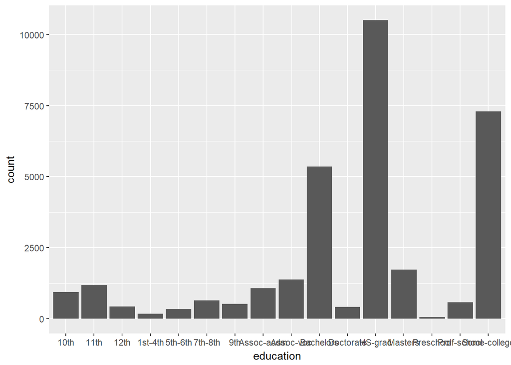

```r
dt %>%
  ggplot(aes(education)) +
  geom_bar()
```

5. Каковы средние значения и среднеквадратичные отклонения возраста тех, кто получает более 50K в год (признак salary) и тех, кто получает менее 50K в год?

```r
dt %>%
  select(salary, age) %>%
  group_by(salary) %>%
  summarise_each(funs(mean, sd))
```

```
## `summarise_each()` is deprecated.
## Use `summarise_all()`, `summarise_at()` or `summarise_if()` instead.
## To map `funs` over all variables, use `summarise_all()`
```

```
## # A tibble: 2 x 3
##   salary     mean       sd
##   <fctr>    <dbl>    <dbl>
## 1  <=50K 36.78374 14.02009
## 2   >50K 44.24984 10.51903
```

6. Правда ли, что люди, которые получают больше 50k, имеют как минимум высшее образование? (признак education - Bachelors, Prof-school, Assoc-acdm, Assoc-voc, Masters или Doctorate)

```r
unique(dt[salary == '>50K', education])
```

```
##  [1] HS-grad      Masters      Bachelors    Some-college Assoc-voc
##  [6] Doctorate    Prof-school  Assoc-acdm   7th-8th      12th
## [11] 10th         11th         9th          5th-6th      1st-4th
## 16 Levels: 10th 11th 12th 1st-4th 5th-6th 7th-8th 9th ... Some-college
```

7. Выведите статистику возраста для каждой расы (признак race) и каждого пола. Используйте groupby и describe. Найдите таким образом максимальный возраст мужчин расы Amer-Indian-Eskimo.

```r
dt %>%
  select(age, sex, race) %>%
  group_by(sex, race) %>%
  summarise_each(funs(max, mean))
```

```
## `summarise_each()` is deprecated.
## Use `summarise_all()`, `summarise_at()` or `summarise_if()` instead.
## To map `funs` over all variables, use `summarise_all()`
```

```
## # A tibble: 10 x 4
## # Groups:   sex [?]
##       sex               race   max     mean
##    <fctr>             <fctr> <dbl>    <dbl>
##  1 Female Amer-Indian-Eskimo    80 37.11765
##  2 Female Asian-Pac-Islander    75 35.08960
##  3 Female              Black    90 37.85402
##  4 Female              Other    74 31.67890
##  5 Female              White    90 36.81162
##  6   Male Amer-Indian-Eskimo    82 37.20833
##  7   Male Asian-Pac-Islander    90 39.07359
##  8   Male              Black    90 37.68260
##  9   Male              Other    77 34.65432
## 10   Male              White    90 39.65250
```

```r
dt %>%
  select(age, sex, race) %>%
  psych::describeBy(c('sex', 'race'))
```

```
##
##  Descriptive statistics by group
## sex: Female
## race: Amer-Indian-Eskimo
##       vars   n  mean    sd median trimmed   mad min max range skew
## age      1 119 37.12 13.11     36    36.3 14.83  17  80    63 0.56
## sex*     2 119  1.00  0.00      1     1.0  0.00   1   1     0  NaN
## race*    3 119  1.00  0.00      1     1.0  0.00   1   1     0  NaN
##       kurtosis  se
## age      -0.21 1.2
## sex*       NaN 0.0
## race*      NaN 0.0
## --------------------------------------------------------
## sex: Male
## race: Amer-Indian-Eskimo
##       vars   n  mean    sd median trimmed   mad min max range skew
## age      1 192 37.21 12.05     35   36.16 11.86  17  82    65 0.83
## sex*     2 192  2.00  0.00      2    2.00  0.00   2   2     0  NaN
## race*    3 192  1.00  0.00      1    1.00  0.00   1   1     0  NaN
##       kurtosis   se
## age        0.6 0.87
## sex*       NaN 0.00
## race*      NaN 0.00
## --------------------------------------------------------
## sex: Female
## race: Asian-Pac-Islander
##       vars   n  mean   sd median trimmed   mad min max range skew kurtosis
## age      1 346 35.09 12.3     33   34.05 13.34  17  75    58 0.76     0.23
## sex*     2 346  1.00  0.0      1    1.00  0.00   1   1     0  NaN      NaN
## race*    3 346  2.00  0.0      2    2.00  0.00   2   2     0  NaN      NaN
##         se
## age   0.66
## sex*  0.00
## race* 0.00
## --------------------------------------------------------
## sex: Male
## race: Asian-Pac-Islander
##       vars   n  mean    sd median trimmed   mad min max range skew
## age      1 693 39.07 12.88     37   37.98 11.86  18  90    72 0.88
## sex*     2 693  2.00  0.00      2    2.00  0.00   2   2     0  NaN
```

[output cut: 56 more lines]

```
##       kurtosis   se
## age      -0.15 0.15
## sex*       NaN 0.00
## race*      NaN 0.00
## --------------------------------------------------------
## sex: Male
## race: White
##       vars     n  mean    sd median trimmed   mad min max range skew
## age      1 19174 39.65 13.44     38    38.9 14.83  17  90    73  0.5
## sex*     2 19174  2.00  0.00      2     2.0  0.00   2   2     0  NaN
## race*    3 19174  5.00  0.00      5     5.0  0.00   5   5     0  NaN
##       kurtosis  se
## age      -0.19 0.1
## sex*       NaN 0.0
## race*      NaN 0.0
```

8. Среди кого больше доля зарабатывающих много (>50K): среди женатых или холостых мужчин (признак marital-status)? Женатыми считаем тех, у кого marital-status начинается с Married (Married-civ-spouse, Married-spouse-absent или Married-AF-spouse), остальных считаем холостыми.

```r
dt[, married := ifelse(regexpr('Married', dt$`marital-status`) == 1, T, F)]
dt[, married := grepl('Married', dt$`marital-status`)]
dt %>%
  filter(salary == '>50K') %>%
  select(salary, married) %>%
  group_by(married) %>%
  table()
```

```
##        married
## salary  FALSE TRUE
##   <=50K     0    0
##   >50K   1105 6736
```

9. Какое максимальное число часов человек работает в неделю (признак hours-per-week)? Сколько людей работают такое количество часов и каков среди них процент зарабатывающих много?

```r
dt %>%
  filter(`hours-per-week` == max(dt$`hours-per-week`)) %>%
  summarise(n = n())
```

```
##    n
## 1 85
```

```r
dt %>%
  filter(`hours-per-week` == max(dt$`hours-per-week`)) %>%
  group_by(salary) %>%
  summarise(n = n())
```

```
## # A tibble: 2 x 2
##   salary     n
##   <fctr> <int>
## 1  <=50K    60
## 2   >50K    25
```

10. Посчитайте среднее время работы (hours-per-week) зарабатывающих мало и много (salary) для каждой страны (native-country).

```r
dt %>%
  select(salary, `hours-per-week`, `native-country`) %>%
  group_by(salary, `native-country`) %>%
  summarise_each(funs(mean))
```

```
## `summarise_each()` is deprecated.
## Use `summarise_all()`, `summarise_at()` or `summarise_if()` instead.
## To map `funs` over all variables, use `summarise_all()`
```

```
## # A tibble: 82 x 3
## # Groups:   salary [?]
##    salary   `native-country` `hours-per-week`
##    <fctr>             <fctr>            <dbl>
##  1  <=50K                  ?         40.16476
##  2  <=50K           Cambodia         41.41667
##  3  <=50K             Canada         37.91463
##  4  <=50K              China         37.38182
##  5  <=50K           Columbia         38.68421
##  6  <=50K               Cuba         37.98571
##  7  <=50K Dominican-Republic         42.33824
##  8  <=50K            Ecuador         38.04167
##  9  <=50K        El-Salvador         36.03093
## 10  <=50K            England         40.48333
## # ... with 72 more rows
```